# Lab1

Joshua Wiseman

2023-01-23

# Tasks

## Task 1

Working directory:

```r
getwd()
```

```
## [1] "/home/joshua/Desktop/MainFolder/OuClasses/Spring 2023/Applied Statistical Methods/FALL224753wise0046/LABS/LAB1"
```

## Task 2

```r
ddt <- read.csv("DDT-1.csv")
head(ddt)
```

```
##   RIVER MILE  SPECIES LENGTH WEIGHT DDT
## 1   FCM    5 CCATFISH   42.5    732  10
## 2   FCM    5 CCATFISH   44.0    795  16
## 3   FCM    5 CCATFISH   41.5    547  23
## 4   FCM    5 CCATFISH   39.0    465  21
## 5   FCM    5 CCATFISH   50.5   1252  50
## 6   FCM    5 CCATFISH   52.0   1255 150
```

## Task 3

### Base Questions

1. What are the qualitative variables in “ddt”? `RIVER & SPECIES`
2. What are the quantitative variables in “ddt”? `MILE, LENGTH, WEIGHT, & DDT`
3. How many SPECIES are in the ddt data set? `3`
4. Subset the ddt data set so that we see only the observations with SPECIES, LMBASS and WEIGHT bigger than 800gms

```r
with(ddt, ddt[WEIGHT>800 & SPECIES=="LMBASS",])
```

```
##     RIVER MILE SPECIES LENGTH WEIGHT DDT
## 141   TRM  345  LMBASS     30    856 2.2
## 144   TRM  345  LMBASS     36   1433 1.9
```

5. Subset the ddt data set so that we see only those observations where the RIVER is SCM and DDT bigger than 4.0

```r
with(ddt, ddt[DDT>4.0 & RIVER=="SCM",])
```

```
##    RIVER MILE  SPECIES LENGTH WEIGHT DDT
## 16   SCM    1 CCATFISH     45    984 9.1
## 17   SCM    1 CCATFISH     43    965 7.8
## 18   SCM    1 CCATFISH     45   1084 4.1
```

### Clicker Questions

1. Find the mean length of fish in the ddt data frame!

```r
mean(ddt$LENGTH)
```

```
## [1] 42.8125
```

2. What is the standard deviation of the weight of fish in the ddt data frame?

```r
sd(ddt$WEIGHT)
```

```
## [1] 376.5461
```

## Task 4

Make a table of the rivers.

```r
rivers <- table(ddt$RIVER)
rivers
```

```
##
## FCM LCM SCM TRM
##   6   6   6 126
```

Make a color coded barplot of the rivers.

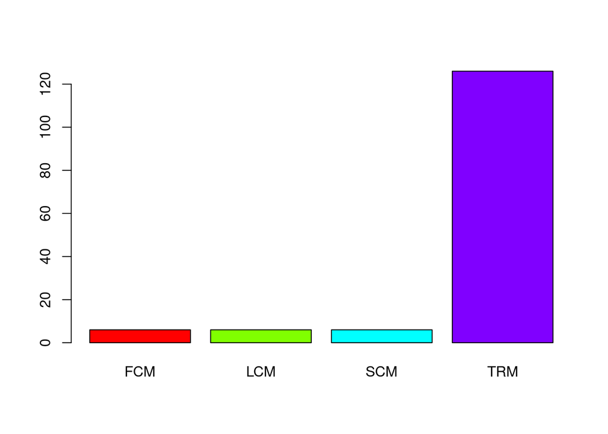

```r
library(ggplot2)
barplot(rivers, col = rainbow(4))
```

Make a table of the rivers crossed with the species of fish.

```r
rivsp <- table(ddt$RIVER, ddt$SPECIES)
rivsp
```

```
##
##       CCATFISH LMBASS SMBUFFALO
##   FCM        6      0         0
##   LCM        6      0         0
##   SCM        6      0         0
##   TRM       78     12        36
```

Make a barplot of the rivers crossed with the species of fish.

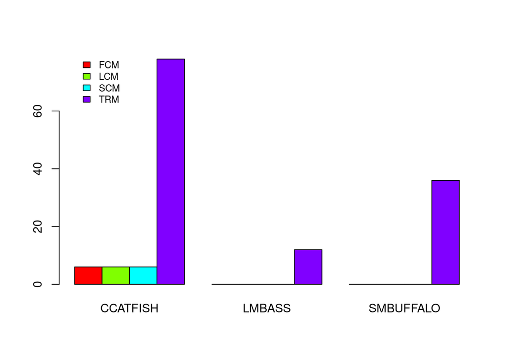

```r
barplot(rivsp, beside=TRUE, col = rainbow(4))
with(ddt, legend(x = 1, y = 80, legend = ddt$RIVER[!(duplicated(ddt$RIVER))], bty = "n", fill = rainbow(4), cex = 0.8))
```

## Task 5

Make a pie chart of Fish SPECIES

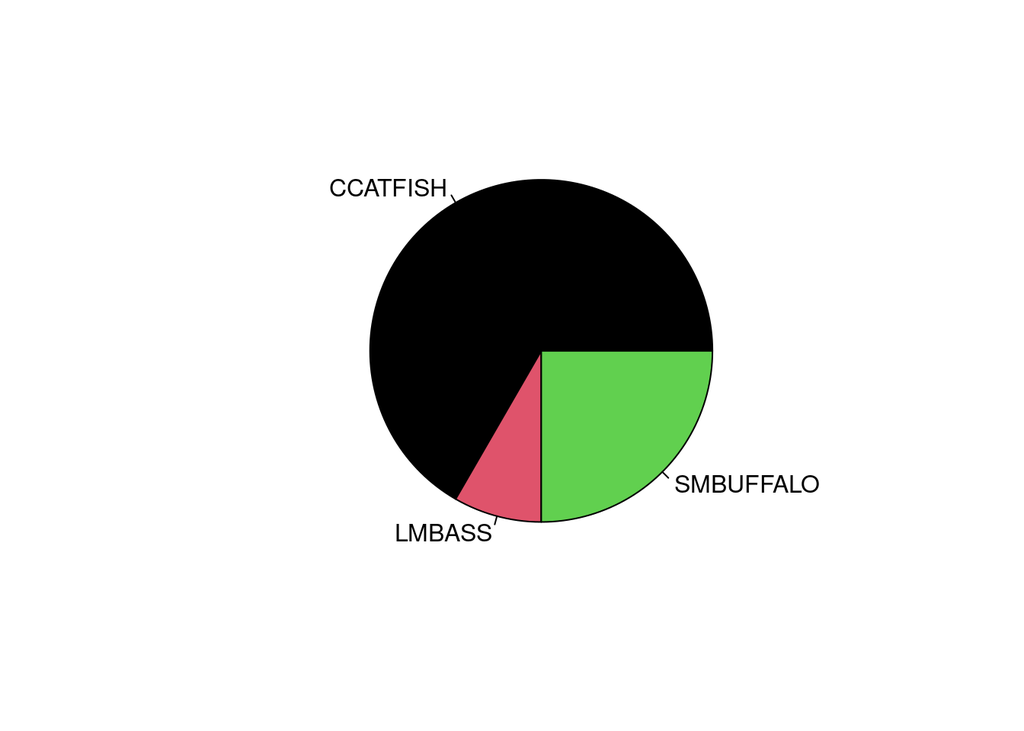

```r
spetab <- table(ddt$SPECIES)
pie(spetab,col=1:4)
```

Make a pie chart of RIVERS

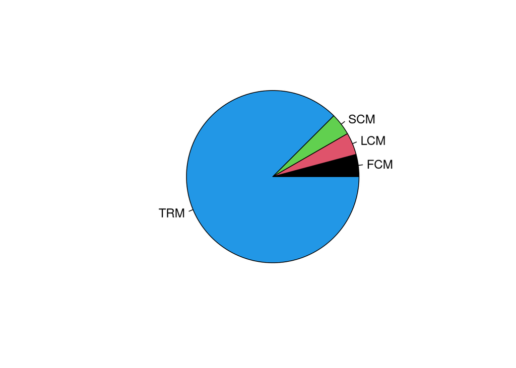

```r
rivtab <- table(ddt$RIVER)
pie(rivtab,col=1:4)
```

## Task 6

Make a boxplot of the variable DDT

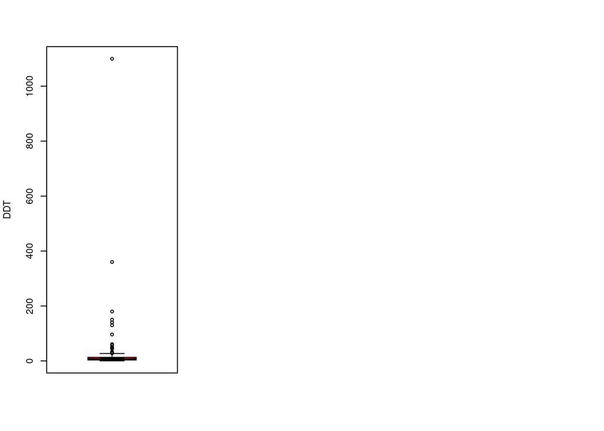

```r
layout(matrix(c(1,2,3),nr=1,nc=3))# 1 row 3 cols
with(ddt,boxplot(DDT,ylab="DDT",col="Red",notch=TRUE))
```

Make a boxplot of the variable WEIGHT

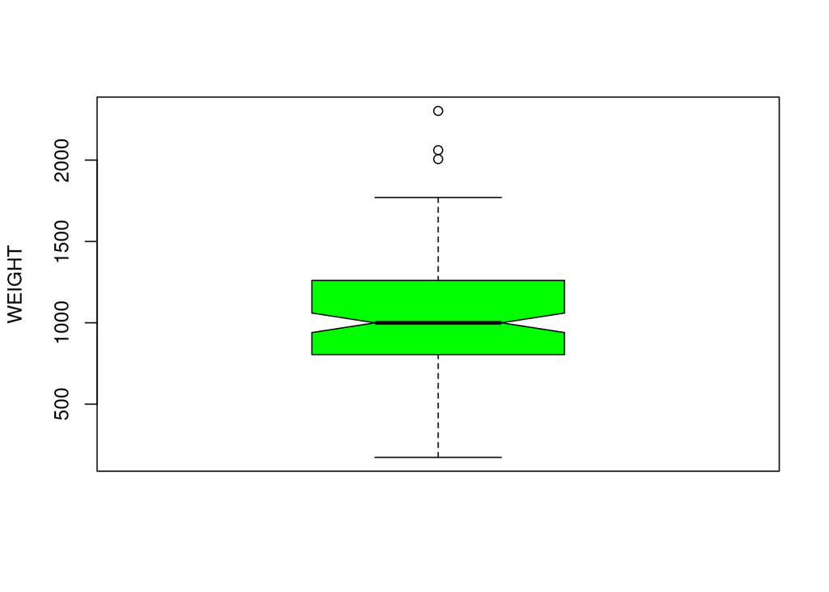

```r
with(ddt,boxplot(WEIGHT,ylab="WEIGHT",col="Green",notch=TRUE))
```

Make a boxplot of the variable LENGTH

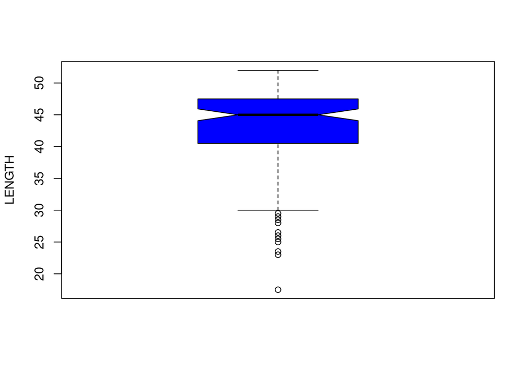

```r
with(ddt,boxplot(LENGTH,ylab="LENGTH",col="Blue",notch=TRUE))
```

## Task 7

Make a coplot of LENGTH Vs WEIGHT given RIVER

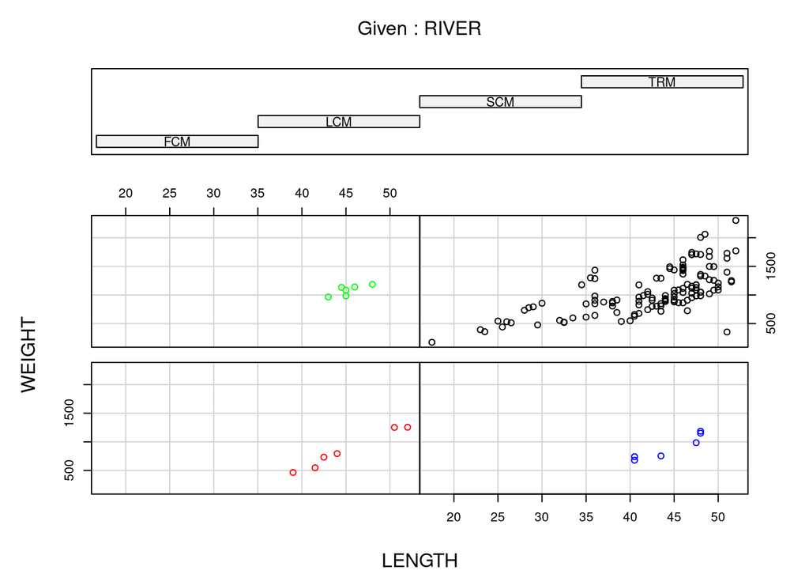

```r
rivcol=with(ddt, ifelse(RIVER=="FCM","Red",
                        ifelse(RIVER=="LCM","Blue",
                               ifelse(RIVER=="SCM","Green","Black"))))
coplot(WEIGHT~LENGTH|RIVER,data=ddt, col = rivcol)
```

Make a coplot of DDT Vs WEIGHT given SPECIES

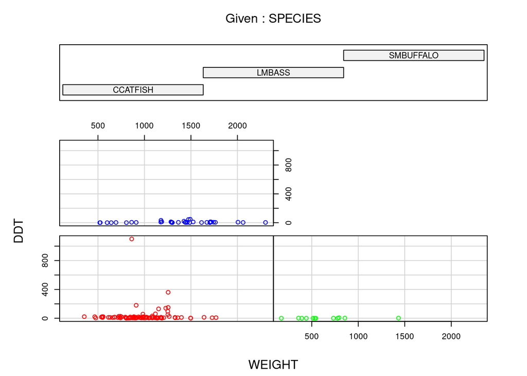

```r
fishcol=with(ddt,ifelse(SPECIES=="CCATFISH","Red",
                        ifelse(SPECIES=="SMBUFFALO","Blue","Green")))
coplot(DDT~WEIGHT|SPECIES,data=ddt, col = fishcol)
```

## Task 8

Graph 1

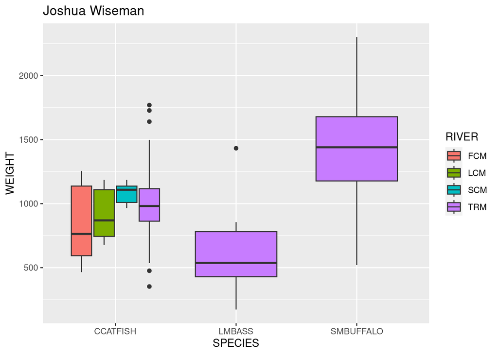

```r
library(ggplot2)
g1 <- ggplot(ddt)
g1 <- g1 + geom_boxplot(aes(x = SPECIES, y = WEIGHT, fill = RIVER)) + ggtitle("Joshua Wiseman")
g1
```

Graph 2

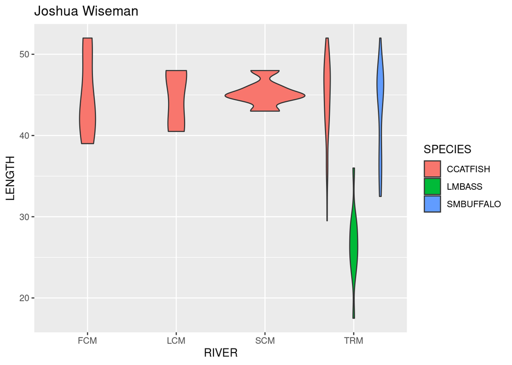

```r
library(ggplot2)
g2 <- ggplot(ddt)
g2 <- g2 + geom_violin(aes(x = RIVER, y = LENGTH, fill = SPECIES)) + ggtitle("Joshua Wiseman")
g2
```

Graph 3

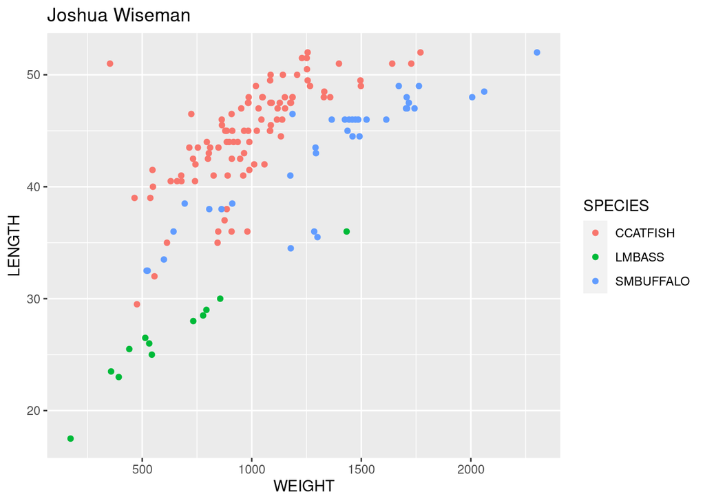

```r
library(ggplot2)
g3 <- ggplot(ddt)
g3 <- g3 + geom_point(aes(x = WEIGHT, y = LENGTH, col = SPECIES)) + ggtitle("Joshua Wiseman")
g3
```